# Report for nova_scotia_kelp

## 1. The Data

Here is your dataset as we reprocessed it. Please take a look.

**Click to see the clean data**

```r
#
 study_data |>
          kable( format = "html") %>%
          kable_styling(position = "center", full_width = F, bootstrap_options = c("striped","hover"))%>%
          scroll_box( width = "1000px", height = "500px", fixed_thead = T)
```

| Entry | Study | Region | Site | Depth.m | Sample.Year | Sample.Month | Sample.Day | Latitude | Longitude | Taxon | Fixed.or.Random | Sample.Unit.Size.sq.m | Percent.Cover | Stipe.Density.num.per.sq.m | Individual.Density.num.per.sq.m | Biomass.kg.wet.per.sq.m |
| --- | --- | --- | --- | --- | --- | --- | --- | --- | --- | --- | --- | --- | --- | --- | --- | --- |
| 1 | nova_scotia_kelp | NA | Coachmans Ledge | 3.5 | 2022 | 8 | NA | 44.49351 | -64.17671 | Laminaria digitata | random | 1 | 0.1000000 | NA | NA | NA |
| 2 | nova_scotia_kelp | NA | Cross Is | 3.5 | 2022 | 8 | NA | 44.31748 | -64.17391 | Laminaria digitata | random | 1 | 72.0750000 | NA | NA | NA |
| 3 | nova_scotia_kelp | NA | E Ironbound Is | 3.5 | 2022 | 8 | NA | 44.43843 | -64.09592 | Laminaria digitata | random | 1 | 0.0250000 | NA | NA | NA |
| 4 | nova_scotia_kelp | NA | E Spectacle Is | 3.5 | 2022 | 8 | NA | 44.24975 | -64.33058 | Laminaria digitata | random | 1 | 21.0714286 | NA | NA | NA |
| 5 | nova_scotia_kelp | NA | Feltzen South | 3.5 | 2022 | 8 | NA | 44.33161 | -64.28214 | Laminaria digitata | random | 1 | 17.4500000 | NA | NA | NA |
| 6 | nova_scotia_kelp | NA | Flat Is | 3.5 | 2022 | 8 | NA | 44.42855 | -64.12989 | Laminaria digitata | random | 1 | 2.4500000 | NA | NA | NA |
| 7 | nova_scotia_kelp | NA | Gill Cove | 3.5 | 2022 | 8 | NA | 44.48522 | -63.53436 | Laminaria digitata | random | 1 | 9.5166667 | NA | NA | NA |
| 8 | nova_scotia_kelp | NA | Grassy Is | 3.5 | 2022 | 8 | NA | 44.44524 | -64.14168 | Laminaria digitata | random | 1 | 0.1000000 | NA | NA | NA |
| 9 | nova_scotia_kelp | NA | Graves Shoal | 3.5 | 2022 | 8 | NA | 44.54774 | -64.19554 | Laminaria digitata | random | 1 | 0.0000000 | NA | NA | NA |
| 10 | nova_scotia_kelp | NA | Kelley Ledge | 3.5 | 2022 | 8 | NA | 44.47746 | -63.77084 | Laminaria digitata | random | 1 | 0.0000000 | NA | NA | NA |
| 11 | nova_scotia_kelp | NA | Little Duck | 3.5 | 2022 | 8 | NA | 44.36425 | -64.18272 | Laminaria digitata | random | 1 | 9.5642857 | NA | NA | NA |
| 12 | nova_scotia_kelp | NA | Little Tancook Is | 3.5 | 2022 | 8 | NA | 44.47489 | -64.13733 | Laminaria digitata | random | 1 | 0.0000000 | NA | NA | NA |
| 13 | nova_scotia_kelp | NA | Luke Is | 3.5 | 2022 | 8 | NA | 44.57912 | -63.94153 | Laminaria digitata | random | 1 | 0.0000000 | NA | NA | NA |
| 14 | nova_scotia_kelp | NA | Lynch Is | 3.5 | 2022 | 8 | NA | 44.51512 | -64.21115 | Laminaria digitata | random | 1 | 0.0000000 | NA | NA | NA |
| 15 | nova_scotia_kelp | NA | Mill Cove B | 3.5 | 2022 | 8 | NA | 44.57985 | -64.05098 | Laminaria digitata | random | 1 | 0.0000000 | NA | NA | NA |
| 16 | nova_scotia_kelp | NA | Ovens | 3.5 | 2022 | 8 | NA | 44.32545 | -64.25922 | Laminaria digitata | random | 1 | 11.2000000 | NA | NA | NA |
| 17 | nova_scotia_kelp | NA | Pennant Is | 3.5 | 2022 | 8 | NA | 44.45579 | -63.66072 | Laminaria digitata | random | 1 | 0.0500000 | NA | NA | NA |
| 18 | nova_scotia_kelp | NA | Pt Enrage | 3.5 | 2022 | 8 | NA | 44.27128 | -64.24710 | Laminaria digitata | random | 1 | 3.1642857 | NA | NA | NA |
| 19 | nova_scotia_kelp | NA | Ringdove Shoal | 3.5 | 2022 | 8 | NA | 44.59600 | -63.96100 | Laminaria digitata | random | 1 | 0.0000000 | NA | NA | NA |
| 20 | nova_scotia_kelp | NA | Rose Bay | 3.5 | 2022 | 8 | NA | 44.29246 | -64.24751 | Laminaria digitata | random | 1 | 1.2654762 | NA | NA | NA |
| 21 | nova_scotia_kelp | NA | Sheep Ledge | 3.5 | 2022 | 8 | NA | 44.50359 | -64.26729 | Laminaria digitata | random | 1 | 0.0500000 | NA | NA | NA |
| 22 | nova_scotia_kelp | NA | Shut-in Is | 3.5 | 2022 | 8 | NA | 44.54116 | -63.95358 | Laminaria digitata | random | 1 | 1.0000000 | NA | NA | NA |
| 23 | nova_scotia_kelp | NA | Tilley Pt | 3.5 | 2022 | 8 | NA | 44.53726 | -64.01675 | Laminaria digitata | random | 1 | 0.0000000 | NA | NA | NA |
| 24 | nova_scotia_kelp | NA | W Ironbound | 3.5 | 2022 | 8 | NA | 44.23824 | -64.27613 | Laminaria digitata | random | 1 | 17.1750000 | NA | NA | NA |
| 25 | nova_scotia_kelp | NA | Woody Is | 3.5 | 2022 | 8 | NA | 44.44942 | -63.71358 | Laminaria digitata | random | 1 | 34.4250000 | NA | NA | NA |
| 26 | nova_scotia_kelp | NA | Coachmans Ledge | 3.5 | 2022 | 8 | NA | 44.49351 | -64.17671 | Saccharina latissima | random | 1 | 29.5750000 | NA | NA | NA |
| 27 | nova_scotia_kelp | NA | Cross Is | 3.5 | 2022 | 8 | NA | 44.31748 | -64.17391 | Saccharina latissima | random | 1 | 2.2750000 | NA | NA | NA |
| 28 | nova_scotia_kelp | NA | E Ironbound Is | 3.5 | 2022 | 8 | NA | 44.43843 | -64.09592 | Saccharina latissima | random | 1 | 0.4750000 | NA | NA | NA |
| 29 | nova_scotia_kelp | NA | E Spectacle Is | 3.5 | 2022 | 8 | NA | 44.24975 | -64.33058 | Saccharina latissima | random | 1 | 0.0964286 | NA | NA | NA |
| 30 | nova_scotia_kelp | NA | Feltzen South | 3.5 | 2022 | 8 | NA | 44.33161 | -64.28214 | Saccharina latissima | random | 1 | 11.5500000 | NA | NA | NA |

[output cut: 87 more lines]

Here is your dataset as where we have now summed across all kelp species and put into the KelpTime main database format.

**Click to see the data in kelptime format**

```r
#|
kelptime_study |>
         kable( format = "html") %>%
         kable_styling(position = "center", full_width = F, bootstrap_options = c("striped","hover"))%>%
         scroll_box( width = "1000px", height = "500px", fixed_thead = T)
```

| study | site | period | latitude | longitude | sample_unit_size_sq_m | sasdate | max_depth | mean_depth | min_depth | biomass_kg_wet_per_sq_m | stipe_density_num_per_sq_m | individual_density_num_per_sq_m | percent_cover | has_bm | has_sd | has_id | has_pc | use_which | focalKelp | focalUnit | geometry | ecoregion | province | realm | focal_std_by_ecoregion | focal_std_by_province | focal_std_by_realm | ln_focal_std_by_ecoregion | ln_focal_std_by_province | … |
| --- | --- | --- | --- | --- | --- | --- | --- | --- | --- | --- | --- | --- | --- | --- | --- | --- | --- | --- | --- | --- | --- | --- | --- | --- | --- | --- | --- | --- | --- | --- |
| nova_scotia_kelp | Coachmans Ledge | 1 | 44.49351 | -64.17671 | 1 | 2000-08-15 | 3.5 | 3.5 | 3.5 | NA | NA | NA | 0.0000000 | 0 | 0 | 0 | 92 | 4 | 0.0000000 | Percent cover | c(-64.17671478, 44.49351453) | Scotian Shelf | Cold Temperate Northwest Atlantic | Temperate Northern Atlantic | 0.0000000 | 0.0000000 | 0.0000000 | -4.6051702 | -4.605170 | … |
| nova_scotia_kelp | Coachmans Ledge | 2 | 44.49351 | -64.17671 | 1 | 2007-08-15 | 3.5 | 3.5 | 3.5 | NA | NA | NA | 67.8000000 | 0 | 0 | 0 | 92 | 4 | 67.8000000 | Percent cover | c(-64.17671478, 44.49351453) | Scotian Shelf | Cold Temperate Northwest Atlantic | Temperate Northern Atlantic | 0.7294338 | 0.2720509 | 0.2720509 | -0.3018706 | -1.265668 | … |
| nova_scotia_kelp | Coachmans Ledge | 3 | 44.49351 | -64.17671 | 1 | 2014-08-15 | 3.5 | 3.5 | 3.5 | NA | NA | NA | 0.5341880 | 0 | 0 | 0 | 92 | 4 | 0.5341880 | Percent cover | c(-64.17671478, 44.49351453) | Scotian Shelf | Cold Temperate Northwest Atlantic | Temperate Northern Atlantic | 0.0057471 | 0.0021435 | 0.0021435 | -4.1510978 | -4.410965 | … |
| nova_scotia_kelp | Coachmans Ledge | 4 | 44.49351 | -64.17671 | 1 | 2022-08-15 | 3.5 | 3.5 | 3.5 | NA | NA | NA | 29.6750000 | 0 | 0 | 0 | 92 | 4 | 29.6750000 | Percent cover | c(-64.17671478, 44.49351453) | Scotian Shelf | Cold Temperate Northwest Atlantic | Temperate Northern Atlantic | 0.3192618 | 0.1190724 | 0.1190724 | -1.1109022 | -2.047382 | … |
| nova_scotia_kelp | Cross Is | 1 | 44.31748 | -64.17391 | 1 | 2000-08-15 | 3.5 | 3.5 | 3.5 | NA | NA | NA | 37.9000000 | 0 | 0 | 0 | 92 | 4 | 37.9000000 | Percent cover | c(-64.17390727, 44.31748417) | Scotian Shelf | Cold Temperate Northwest Atlantic | Temperate Northern Atlantic | 0.4077513 | 0.1520756 | 0.1520756 | -0.8728689 | -1.819692 | … |
| nova_scotia_kelp | Cross Is | 2 | 44.31748 | -64.17391 | 1 | 2007-08-15 | 3.5 | 3.5 | 3.5 | NA | NA | NA | 73.3000000 | 0 | 0 | 0 | 92 | 4 | 73.3000000 | Percent cover | c(-64.17390727, 44.31748417) | Scotian Shelf | Cold Temperate Northwest Atlantic | Temperate Northern Atlantic | 0.7886061 | 0.2941199 | 0.2941199 | -0.2248874 | -1.190333 | … |
| nova_scotia_kelp | Cross Is | 3 | 44.31748 | -64.17391 | 1 | 2014-08-15 | 3.5 | 3.5 | 3.5 | NA | NA | NA | 44.4942044 | 0 | 0 | 0 | 92 | 4 | 44.4942044 | Percent cover | c(-64.17390727, 44.31748417) | Scotian Shelf | Cold Temperate Northwest Atlantic | Temperate Northern Atlantic | 0.4786958 | 0.1785352 | 0.1785352 | -0.7160151 | -1.668470 | … |
| nova_scotia_kelp | Cross Is | 4 | 44.31748 | -64.17391 | 1 | 2022-08-15 | 3.5 | 3.5 | 3.5 | NA | NA | NA | 74.3500000 | 0 | 0 | 0 | 92 | 4 | 74.3500000 | Percent cover | c(-64.17390727, 44.31748417) | Scotian Shelf | Cold Temperate Northwest Atlantic | Temperate Northern Atlantic | 0.7999027 | 0.2983331 | 0.2983331 | -0.2108412 | -1.176575 | … |
| nova_scotia_kelp | E Ironbound Is | 1 | 44.43843 | -64.09592 | 1 | 2000-08-15 | 3.5 | 3.5 | 3.5 | NA | NA | NA | 0.6000000 | 0 | 0 | 0 | 92 | 4 | 0.6000000 | Percent cover | c(-64.09592455, 44.43843311) | Scotian Shelf | Cold Temperate Northwest Atlantic | Temperate Northern Atlantic | 0.0064552 | 0.0024075 | 0.0024075 | -4.1071158 | -4.389452 | … |
| nova_scotia_kelp | E Ironbound Is | 2 | 44.43843 | -64.09592 | 1 | 2007-08-15 | 3.5 | 3.5 | 3.5 | NA | NA | NA | 15.9000000 | 0 | 0 | 0 | 92 | 4 | 15.9000000 | Percent cover | c(-64.09592455, 44.43843311) | Scotian Shelf | Cold Temperate Northwest Atlantic | Temperate Northern Atlantic | 0.1710619 | 0.0637995 | 0.0637995 | -1.7089163 | -2.606403 | … |
| nova_scotia_kelp | E Ironbound Is | 3 | 44.43843 | -64.09592 | 1 | 2014-08-15 | 3.5 | 3.5 | 3.5 | NA | NA | NA | 11.3942308 | 0 | 0 | 0 | 92 | 4 | 11.3942308 | Percent cover | c(-64.09592455, 44.43843311) | Scotian Shelf | Cold Temperate Northwest Atlantic | Temperate Northern Atlantic | 0.1225861 | 0.0457199 | 0.0457199 | -2.0205231 | -2.887418 | … |
| nova_scotia_kelp | E Ironbound Is | 4 | 44.43843 | -64.09592 | 1 | 2022-08-15 | 3.5 | 3.5 | 3.5 | NA | NA | NA | 0.5000000 | 0 | 0 | 0 | 92 | 4 | 0.5000000 | Percent cover | c(-64.09592455, 44.43843311) | Scotian Shelf | Cold Temperate Northwest Atlantic | Temperate Northern Atlantic | 0.0053793 | 0.0020063 | 0.0020063 | -4.1747325 | -4.422326 | … |
| nova_scotia_kelp | E Spectacle Is | 1 | 44.24975 | -64.33058 | 1 | 2000-08-15 | 3.5 | 3.5 | 3.5 | NA | NA | NA | 0.6000000 | 0 | 0 | 0 | 92 | 4 | 0.6000000 | Percent cover | c(-64.33058306, 44.24974658) | Scotian Shelf | Cold Temperate Northwest Atlantic | Temperate Northern Atlantic | 0.0064552 | 0.0024075 | 0.0024075 | -4.1071158 | -4.389452 | … |
| nova_scotia_kelp | E Spectacle Is | 2 | 44.24975 | -64.33058 | 1 | 2007-08-15 | 3.5 | 3.5 | 3.5 | NA | NA | NA | 9.9000000 | 0 | 0 | 0 | 92 | 4 | 9.9000000 | Percent cover | c(-64.33058306, 44.24974658) | Scotian Shelf | Cold Temperate Northwest Atlantic | Temperate Northern Atlantic | 0.1065102 | 0.0397242 | 0.0397242 | -2.1497761 | -3.001263 | … |
| nova_scotia_kelp | E Spectacle Is | 3 | 44.24975 | -64.33058 | 1 | 2014-08-15 | 3.5 | 3.5 | 3.5 | NA | NA | NA | 17.3798077 | 0 | 0 | 0 | 92 | 4 | 17.3798077 | Percent cover | c(-64.33058306, 44.24974658) | Scotian Shelf | Cold Temperate Northwest Atlantic | Temperate Northern Atlantic | 0.1869826 | 0.0697373 | 0.0697373 | -1.6246400 | -2.529017 | … |
| nova_scotia_kelp | E Spectacle Is | 4 | 44.24975 | -64.33058 | 1 | 2022-08-15 | 3.5 | 3.5 | 3.5 | NA | NA | NA | 21.1678571 | 0 | 0 | 0 | 92 | 4 | 21.1678571 | Percent cover | c(-64.33058306, 44.24974658) | Scotian Shelf | Cold Temperate Northwest Atlantic | Temperate Northern Atlantic | 0.2277367 | 0.0849371 | 0.0849371 | -1.4365914 | -2.354541 | … |
| nova_scotia_kelp | Feltzen South | 1 | 44.33161 | -64.28214 | 1 | 2000-08-15 | 3.5 | 3.5 | 3.5 | NA | NA | NA | 0.3000000 | 0 | 0 | 0 | 92 | 4 | 0.3000000 | Percent cover | c(-64.28214228, 44.33160902) | Scotian Shelf | Cold Temperate Northwest Atlantic | Temperate Northern Atlantic | 0.0032276 | 0.0012038 | 0.0012038 | -4.3254510 | -4.491505 | … |
| nova_scotia_kelp | Feltzen South | 2 | 44.33161 | -64.28214 | 1 | 2007-08-15 | 3.5 | 3.5 | 3.5 | NA | NA | NA | 15.3000000 | 0 | 0 | 0 | 92 | 4 | 15.3000000 | Percent cover | c(-64.28214228, 44.33160902) | Scotian Shelf | Cold Temperate Northwest Atlantic | Temperate Northern Atlantic | 0.1646067 | 0.0613920 | 0.0613920 | -1.7452191 | -2.639569 | … |
| nova_scotia_kelp | Feltzen South | 3 | 44.33161 | -64.28214 | 1 | 2014-08-15 | 3.5 | 3.5 | 3.5 | NA | NA | NA | 17.7426740 | 0 | 0 | 0 | 92 | 4 | 17.7426740 | Percent cover | c(-64.28214228, 44.33160902) | Scotian Shelf | Cold Temperate Northwest Atlantic | Temperate Northern Atlantic | 0.1908865 | 0.0711934 | 0.0711934 | -1.6050151 | -2.510922 | … |
| nova_scotia_kelp | Feltzen South | 4 | 44.33161 | -64.28214 | 1 | 2022-08-15 | 3.5 | 3.5 | 3.5 | NA | NA | NA | 29.0000000 | 0 | 0 | 0 | 92 | 4 | 29.0000000 | Percent cover | c(-64.28214228, 44.33160902) | Scotian Shelf | Cold Temperate Northwest Atlantic | Temperate Northern Atlantic | 0.3119997 | 0.1163639 | 0.1163639 | -1.1332047 | -2.068589 | … |
| nova_scotia_kelp | Flat Is | 1 | 44.42855 | -64.12989 | 1 | 2000-08-15 | 3.5 | 3.5 | 3.5 | NA | NA | NA | 1.5000000 | 0 | 0 | 0 | 92 | 4 | 1.5000000 | Percent cover | c(-64.12988601, 44.42854791) | Scotian Shelf | Cold Temperate Northwest Atlantic | Temperate Northern Atlantic | 0.0161379 | 0.0060188 | 0.0060188 | -3.6443683 | -4.133991 | … |
| nova_scotia_kelp | Flat Is | 2 | 44.42855 | -64.12989 | 1 | 2007-08-15 | 3.5 | 3.5 | 3.5 | NA | NA | NA | 9.0000000 | 0 | 0 | 0 | 92 | 4 | 9.0000000 | Percent cover | c(-64.12988601, 44.42854791) | Scotian Shelf | Cold Temperate Northwest Atlantic | Temperate Northern Atlantic | 0.0968275 | 0.0361129 | 0.0361129 | -2.2365400 | -3.076662 | … |
| nova_scotia_kelp | Flat Is | 3 | 44.42855 | -64.12989 | 1 | 2014-08-15 | 3.5 | 3.5 | 3.5 | NA | NA | NA | 4.2067308 | 0 | 0 | 0 | 92 | 4 | 4.2067308 | Percent cover | c(-64.12988601, 44.42854791) | Scotian Shelf | Cold Temperate Northwest Atlantic | Temperate Northern Atlantic | 0.0452586 | 0.0168797 | 0.0168797 | -2.8957317 | -3.616383 | … |
| nova_scotia_kelp | Flat Is | 4 | 44.42855 | -64.12989 | 1 | 2022-08-15 | 3.5 | 3.5 | 3.5 | NA | NA | NA | 2.9500000 | 0 | 0 | 0 | 92 | 4 | 2.9500000 | Percent cover | c(-64.12988601, 44.42854791) | Scotian Shelf | Cold Temperate Northwest Atlantic | Temperate Northern Atlantic | 0.0317379 | 0.0118370 | 0.0118370 | -3.1763457 | -3.824149 | … |
| nova_scotia_kelp | Gill Cove | 1 | 44.48522 | -63.53436 | 1 | 2000-08-15 | 3.5 | 3.5 | 3.5 | NA | NA | NA | 25.6000000 | 0 | 0 | 0 | 92 | 4 | 25.6000000 | Percent cover | c(-63.53436, 44.48522) | Scotian Shelf | Cold Temperate Northwest Atlantic | Temperate Northern Atlantic | 0.2754204 | 0.1027213 | 0.1027213 | -1.2537920 | -2.182837 | … |
| nova_scotia_kelp | Gill Cove | 2 | 44.48522 | -63.53436 | 1 | 2007-08-15 | 3.5 | 3.5 | 3.5 | NA | NA | NA | 76.7000000 | 0 | 0 | 0 | 92 | 4 | 76.7000000 | Percent cover | c(-63.53436, 44.48522) | Scotian Shelf | Cold Temperate Northwest Atlantic | Temperate Northern Atlantic | 0.8251854 | 0.3077626 | 0.3077626 | -0.1801015 | -1.146451 | … |
| nova_scotia_kelp | Gill Cove | 3 | 44.48522 | -63.53436 | 1 | 2014-08-15 | 3.5 | 3.5 | 3.5 | NA | NA | NA | 28.9423077 | 0 | 0 | 0 | 92 | 4 | 28.9423077 | Percent cover | c(-63.53436, 44.48522) | Scotian Shelf | Cold Temperate Northwest Atlantic | Temperate Northern Atlantic | 0.3113790 | 0.1161324 | 0.1161324 | -1.1351341 | -2.070423 | … |
| nova_scotia_kelp | Gill Cove | 4 | 44.48522 | -63.53436 | 1 | 2022-08-15 | 3.5 | 3.5 | 3.5 | NA | NA | NA | 21.7869048 | 0 | 0 | 0 | 92 | 4 | 21.7869048 | Percent cover | c(-63.53436, 44.48522) | Scotian Shelf | Cold Temperate Northwest Atlantic | Temperate Northern Atlantic | 0.2343968 | 0.0874210 | 0.0874210 | -1.4089621 | -2.328713 | … |
| nova_scotia_kelp | Grassy Is | 1 | 44.44524 | -64.14168 | 1 | 2000-08-15 | 3.5 | 3.5 | 3.5 | NA | NA | NA | 0.5000000 | 0 | 0 | 0 | 92 | 4 | 0.5000000 | Percent cover | c(-64.14167508, 44.44524131) | Scotian Shelf | Cold Temperate Northwest Atlantic | Temperate Northern Atlantic | 0.0053793 | 0.0020063 | 0.0020063 | -4.1747325 | -4.422326 | … |
| nova_scotia_kelp | Grassy Is | 2 | 44.44524 | -64.14168 | 1 | 2007-08-15 | 3.5 | 3.5 | 3.5 | NA | NA | NA | 35.6000000 | 0 | 0 | 0 | 92 | 4 | 35.6000000 | Percent cover | c(-64.14167508, 44.44524131) | Scotian Shelf | Cold Temperate Northwest Atlantic | Temperate Northern Atlantic | 0.3830065 | 0.1428468 | 0.1428468 | -0.9339291 | -1.878319 | … |

[output cut: 62 more lines]

## 2. Plots of raw data

### 2.1 By metric

Here is what your data looks like with all sites plotted together looking at each sampling metric.

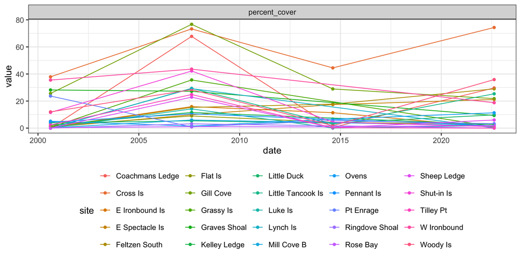

```r
kelptime_study_measurement_long <-
  kelptime_study |>
  tidyr::pivot_longer(cols =biomass_kg_wet_per_sq_m:percent_cover) |>
  filter(!is.na(value))

ggplot(kelptime_study_measurement_long,
       aes(x = date, y = value,
           color = site)) +
  geom_point() +
  geom_line() +
  facet_wrap(vars(name), scale = "free_y")
```

### 2.2 Standardized data

Here is what your data looks like with all sites plotted together where we take the preferred metric (order of preference: biomass, percent cover, individual count) and standardize it by dividing it by the highest value in the Ecoregion.

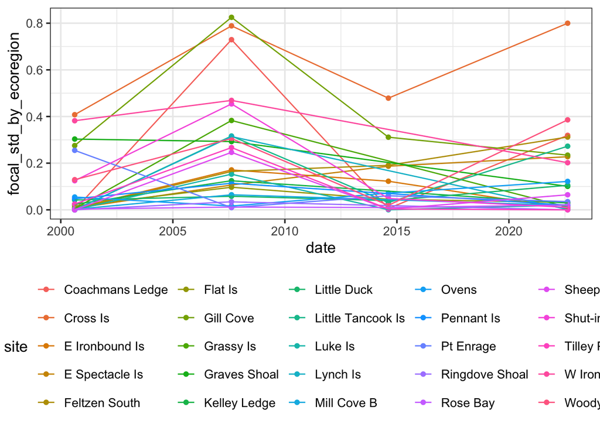

```r
ggplot(kelptime_study,
       aes(x = date, y = focal_std_by_ecoregion,
           color = site)) +
  geom_point() +
  geom_line()
```

### 2.3 Standardized data by site

Here is what your data looks like with all sites plotted together where we take the preferred metric (order of preference: biomass, percent cover, individual count) and standardize it by dividing it by the highest value in the Ecoregion. We then facet by site so that you can look at each site indivudally to assess if trends look accurate.

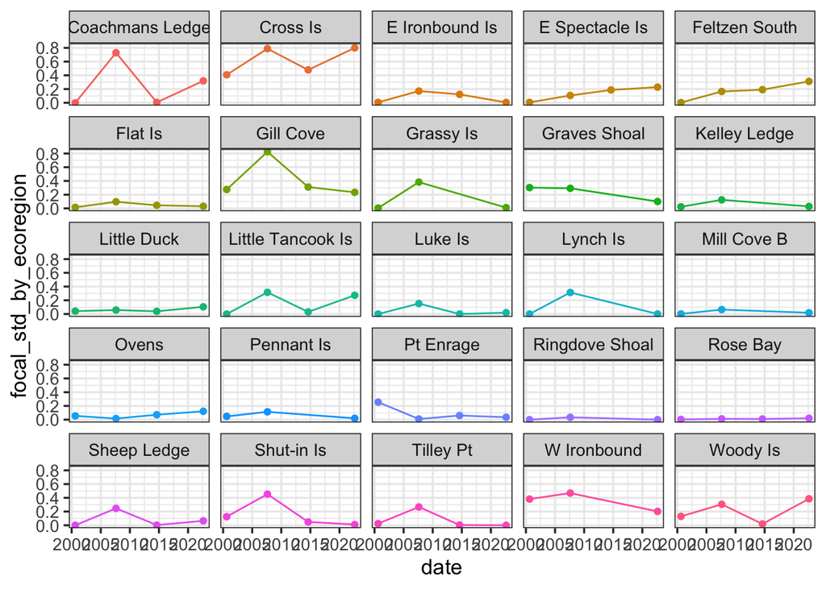

```r
ggplot(kelptime_study,
       aes(x = date, y = focal_std_by_ecoregion,
           color = site)) +
  geom_point() +
  geom_line() +
  facet_wrap(vars(site)) +
  guides(color = "none")
```

## 3. Modeled timeseries resuls

We fit two models. One where the slope varies by ecoregion (note: the GOSL and Newfoundland are collapsed) and one where the slope does not vary by ecoregion. Based on the modeled results, here is the smoothed fits to your data. Note - thus far, the model with a common slope appears to be the correct is the one with a common slope (best fit in terms of prediction and p-value for slope*ecoregion is not distinguishable from 0).

**Note** - the study (black) line might not line up in the middle or on trajectories, as it is shrunken in towards the grand mean for the ecoregion.

### 3.1 Slope Varying by Ecoregion Model

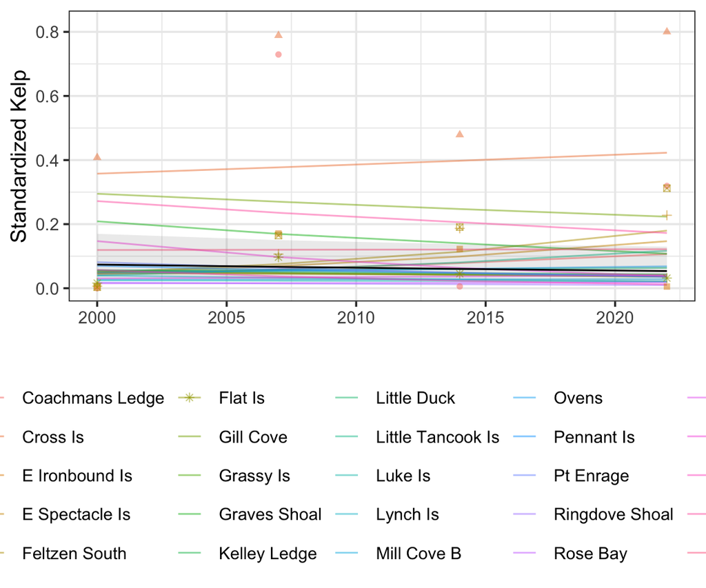

```r
mod_ecoregion <- readRDS("models/mod_ecoregion.rds")


# for plotting to do the back transform
exp_trans <- function(dat){

  dat |>
    mutate(
      Predicted = exp(Predicted)-0.01,
           CI_low = exp(CI_low)-0.01,
           CI_high = exp(CI_high)-0.01,
           CI_high = ifelse(CI_high>1.1, 1.1, CI_high)
    )|>
               mutate(trajectory =
                        gsub(study[1], "", trajectory))

}


re_ecoregion <- ranef(mod_ecoregion)$cond$study |>
  as_tibble(rownames = "study")  |>
  filter(study == params$study) |>
  pull(`(Intercept)`)


dat_fixed_ecoregion <- estimate_relation(mod_ecoregion,
                               include_random = FALSE,
                  length = 200,
                  data = kelptime_study) |>
  mutate(Predicted = Predicted + re_ecoregion,
         CI_high = CI_high + re_ecoregion,
         CI_low = CI_low + re_ecoregion) |>
  exp_trans()

dat_traj_ecoregion <- estimate_relation(mod_ecoregion,
                              include_random = TRUE,
                  length = 200,
                  data = kelptime_study) |>
    exp_trans()


ggplot(dat_traj_ecoregion, aes(x = year)) +
  geom_line(aes(y = Predicted,
                color = trajectory), alpha = 0.5) +
  geom_point(aes(y = focal_std_by_ecoregion,
                 group = trajectory,
                 shape = trajectory,
                 color = trajectory), alpha = 0.5,
             data = kelptime_study |>
               mutate(trajectory =
                        gsub(study[1], "", trajectory))) +
  geom_line(data = dat_fixed_ecoregion,
            aes(y = Predicted), color = "black") +
  geom_ribbon(data = dat_fixed_ecoregion,
            aes(y = Predicted,
                ymin = CI_low,
                ymax = CI_high), color = NA,
            alpha = 0.1) +
  labs(x = "", y = "Standardized Kelp",
      color = "site", shape = "site")
```

### 3.2 Common Slope Model

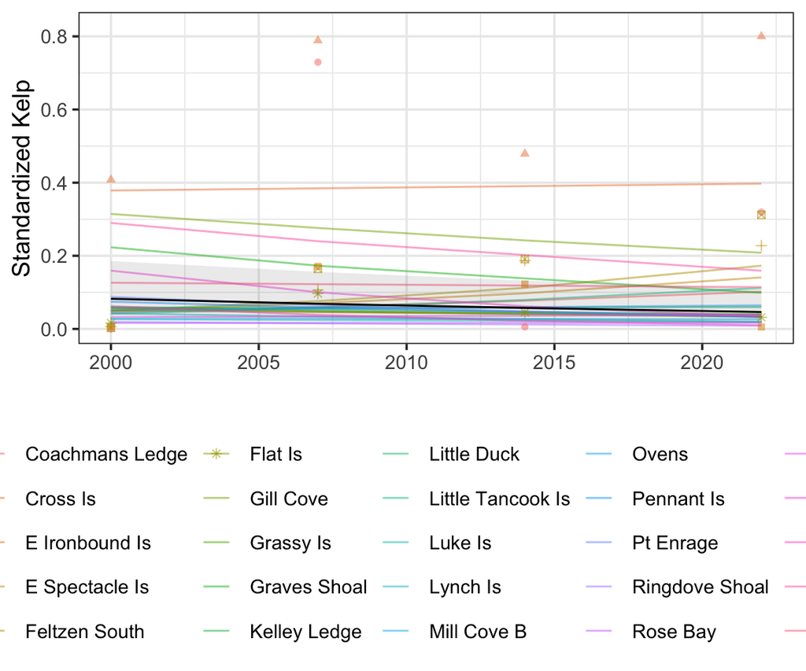

```r
mod_common_slope <- readRDS("models/mod_common_slope.rds")

re <- ranef(mod_common_slope)$cond$study |>
  as_tibble(rownames = "study")  |>
  filter(study == params$study) |>
  pull(`(Intercept)`)


dat_fixed <- estimate_relation(mod_common_slope,
                               include_random = FALSE,
                  length = 200,
                  data = kelptime_study) |>
  mutate(Predicted = Predicted + re,
         CI_high = CI_high + re_ecoregion,
         CI_low = CI_low + re_ecoregion) |>
  exp_trans()

dat_traj <- estimate_relation(mod_common_slope,
                              include_random = TRUE,
                  length = 200,
                  data = kelptime_study) |>
    exp_trans()

ggplot(dat_traj, aes(x = year)) +
  geom_line(aes(y = Predicted,
                color = trajectory), alpha = 0.5) +
  geom_point(aes(y = focal_std_by_ecoregion,
                 group = trajectory,
                 shape = trajectory,
                 color = trajectory), alpha = 0.5,
             data = kelptime_study |>
               mutate(trajectory =
                        gsub(study[1], "", trajectory))) +
  geom_line(data = dat_fixed,
            aes(y = Predicted), color = "black") +
  geom_ribbon(data = dat_fixed,
            aes(y = Predicted,
                ymin = CI_low,
                ymax = CI_high), color = NA,
            alpha = 0.1) +
  labs(x = "", y = "Standardized Kelp",
      color = "site", shape = "site")
```